# ST2195 Programming for Data Science

Coursework 2 – 2009 ASA Flight Data Analysis (2004–2008)

This notebook answers all three questions using US domestic flight data from 2004 to 2008. All CSV files must be placed in a `data/` subfolder next to this `.Rmd` file.

**Questions**

- **Question A** – What are the best times and days of the week to minimise delays each year?
- **Question B** – Do older planes suffer more delays on a year-to-year basis?
- **Question C** – Fit a logistic regression model for the probability of diverted flights and visualise how the coefficients change across years.

**Data files required** (place inside `data/`)

| File | Description |
| --- | --- |
| `2004.csv` – `2008.csv` | Flight records for each year |
| `airports.csv` | Airport IATA codes with state, latitude and longitude |
| `plane-data.csv` | Aircraft tail numbers with manufacture year |
| `carriers.csv` | IATA carrier codes mapped to full airline names |
| `data/shapefiles/cb_2024_us_state_500k.shp` | US state shapefile for Question C maps |

# 1. Setup

Loads all packages, sets constants, and resolves paths.

| Constant | Default | Purpose |
| --- | --- | --- |
| `CHUNK_SIZE` | 200,000 | Rows per fread iteration in Question C |
| `SAMPLE_SIZE` | 5,000,000 | Max flights sampled per year in Part C |
| `TRAIN_YEARS` | 2004–2007 | Years used to train the prediction model |
| `TEST_YEAR` | 2008 | Year held out for testing |

```r
# ── Packages
suppressPackageStartupMessages({
  library(data.table)   # fast file reading and data manipulation
  library(dplyr)        # pipe operator and tidy verbs
  library(readr)        # used only for plane-data.csv (handles BOM/encoding reliably)
  library(ggplot2)      # all plots
  library(patchwork)    # combining multiple ggplot panels
  library(scales)       # colour scale helpers (squish, etc.)
  library(RColorBrewer) # diverging palettes for heatmaps
  library(glmnet)       # ridge logistic regression (L2 penalty)
  library(Matrix)       # sparse.model.matrix for one-hot encoding
  library(pROC)         # ROC curve and AUC
  library(sf)           # US state shapefiles
})

options(datatable.showProgress = FALSE)

# Paths
# BASE_DIR resolves to the folder containing this .Rmd file.
# All CSV files must sit inside BASE_DIR/data/.
BASE_DIR <- getwd()
DATA_DIR <- file.path(BASE_DIR, "data")

# Constants
YEARS       <- c(2004L, 2005L, 2006L, 2007L, 2008L)
TRAIN_YEARS <- c(2004L, 2005L, 2006L, 2007L)
TEST_YEAR   <- 2008L
CHUNK_SIZE  <- 200000L

# Max rows sampled per year in Part C.
SAMPLE_SIZE <- 5000000L

set.seed(42L)  # ensures reproducible sampling across all questions

# Day-of-week label maps (1=Monday … 7=Sunday, matching the raw data)
DAY_LABELS <- c(
  "1"="Monday",   "2"="Tuesday", "3"="Wednesday",
  "4"="Thursday", "5"="Friday",  "6"="Saturday", "7"="Sunday"
)
DAY_LABELS_SHORT <- c(
  "1"="Mon", "2"="Tue", "3"="Wed",
  "4"="Thu", "5"="Fri", "6"="Sat", "7"="Sun"
)

# Consistent year colours used across all plots
YEAR_COLORS <- c(
  "2004" = "#1565C0", "2005" = "#2E7D32",
  "2006" = "#E65100", "2007" = "#6A1B9A", "2008" = "#C62828"
)
```

# 2. Load Supplementary Lookup Tables

**airports.csv** – IATA code → state, latitude, longitude. Used in Part C to add geographic features to each flight.

**plane-data.csv** – Tail number → manufacture year. Used in Parts B and C to compute plane age.

**carriers.csv** – IATA carrier code → full airline name. Loaded here and kept in memory so it is available throughout the notebook for carrier name resolution in Question C.

All three files are small enough to load fully. `airports.csv` and `plane-data.csv` are stored as **named vectors** for O(1) lookups inside chunk loops. `carriers.csv` is stored as a named character vector indexed by IATA code.

Where a tail number is not found in the plane lookup, the **global median manufacture year** is used as a fallback. This avoids discarding flights with unmatched tail numbers while keeping plane age reasonable.

```r
# airports.csv — loaded with fread (plain ASCII, no encoding issues)
airports_raw <- fread(
  file.path(DATA_DIR, "airports.csv"),
  select = c("iata", "state", "lat", "long")
)
airports_raw <- airports_raw[!is.na(iata)]
airports_raw[is.na(state), state := "Unknown"]
airports_raw[, lat  := suppressWarnings(as.numeric(lat))]
airports_raw[, long := suppressWarnings(as.numeric(long))]

# Global mean coordinates — used when an IATA code is not in the lookup
mean_lat <- mean(airports_raw$lat,  na.rm = TRUE)
mean_lon <- mean(airports_raw$long, na.rm = TRUE)

# Named vectors for fast in-loop lookup
origin_state_lkp <- setNames(airports_raw$state, airports_raw$iata)
origin_lat_lkp   <- setNames(airports_raw$lat,   airports_raw$iata)
origin_lon_lkp   <- setNames(airports_raw$long,  airports_raw$iata)

# plane-data.csv — loaded with read_csv to handle BOM / encoding reliably
planes_raw <- read_csv(
  file.path(DATA_DIR, "plane-data.csv"),
  show_col_types = FALSE
) %>%
  dplyr::select(TailNum = tailnum, MfgYear = year) %>%
  dplyr::mutate(MfgYear = suppressWarnings(as.numeric(MfgYear)))

plane_lkp         <- setNames(planes_raw$MfgYear, planes_raw$TailNum)
global_mfg_median <- median(planes_raw$MfgYear, na.rm = TRUE)

# carriers.csv — IATA code → full airline name
carriers_raw <- fread(file.path(DATA_DIR, "carriers.csv"), showProgress = FALSE)
carriers_raw[, names(carriers_raw) := lapply(.SD, as.character)]
code_col_r <- names(carriers_raw)[grepl("code", names(carriers_raw), ignore.case = TRUE)][1]
name_col_r <- setdiff(names(carriers_raw), code_col_r)[1]
carrier_name_lkp <- setNames(trimws(carriers_raw[[name_col_r]]),
                              trimws(carriers_raw[[code_col_r]]))

rm(airports_raw, planes_raw, carriers_raw)
invisible(gc())
```

# 3. Shared Feature Engineering (Question C)

This section defines the feature set and helper functions used throughout Question C. All feature engineering is centralised here so the same logic applies consistently across training years, the test year, and the EDA sample.

Two design choices are worth noting upfront. First, only columns available **before** a flight departs are included — post-flight fields like `WeatherDelay` or `ArrDelay` are excluded to prevent data leakage into the diversion model. Second, geographic coordinates for both origin and destination airports are added as continuous features, allowing the model to pick up any spatial patterns in diversion risk without one-hot encoding every individual airport.

## Feature lists

```r
# Numeric features — standardised (z-score) before modelling
NUMERIC_FEATURES_C <- c(
  "Distance", "PlaneAge",
  "Month", "DayofMonth", "DayOfWeek",
  "DepHour", "ArrHour",
  "Origin_Lat", "Origin_Lon",
  "Dest_Lat",   "Dest_Lon"
)

# Categorical features — one-hot encoded via sparse.model.matrix
CAT_FEATURES_C <- c("UniqueCarrier", "Origin_State", "Dest_State")
ALL_FEATURES_C <- c(NUMERIC_FEATURES_C, CAT_FEATURES_C)

# Columns to read from the raw CSV (minimal set to reduce memory)
COLS_NEEDED_C <- c(
  "Month", "DayofMonth", "DayOfWeek",
  "CRSDepTime", "CRSArrTime",
  "UniqueCarrier", "TailNum",
  "Origin", "Dest", "Distance", "Diverted"
)
```

## `engineer_chunk()`

Takes a raw `data.table` chunk and returns it with all model features attached. Each transformation is applied in place to avoid unnecessary copies. Key steps are:

- **Departure and arrival hour** are extracted from the 4-digit HHMM scheduled time fields (`CRSDepTime`, `CRSArrTime`) using integer division, then wrapped modulo 24 to handle the edge case of midnight schedules stored as 2400.
- **Origin and destination features** (state, latitude, longitude) are added via O(1) named-vector lookups against the airport table loaded in Section 2. Missing IATA codes fall back to the global mean coordinates rather than producing NA values that would break the sparse matrix construction.
- **Plane age** is computed as `flight_year − MfgYear`, then clipped to the interval [0, 80] to remove implausible values caused by data entry errors in the tail-number registry.

```r
#' Add model features to a raw chunk of flight data
#'
#' @param chunk       data.table of raw flight rows
#' @param flight_year integer year of the flights (used to compute PlaneAge)
#' @return data.table with ALL_FEATURES_C + Diverted, or NULL if the chunk is empty
engineer_chunk <- function(chunk, flight_year) {
  dt <- copy(chunk)

  # Drop rows where the target is missing
  dt <- dt[!is.na(Diverted)]
  if (nrow(dt) == 0L) return(NULL)

  dt[, Diverted := as.integer(Diverted)]

  # Departure and arrival hour from 4-digit HHMM format (e.g. 1435 → 14)
  dt[, DepHour := (as.integer(fifelse(is.na(CRSDepTime), 0L,
                                       as.integer(CRSDepTime))) %/% 100L) %% 24L]
  dt[, ArrHour := (as.integer(fifelse(is.na(CRSArrTime), 0L,
                                       as.integer(CRSArrTime))) %/% 100L) %% 24L]

  # Distance — coerce to numeric, fill missing with 0
  dt[, Distance := {
    d <- suppressWarnings(as.numeric(Distance))
    fifelse(is.na(d), 0, d)
  }]

  # Origin airport: state and coordinates via named-vector lookup
  dt[, Origin_State := fifelse(is.na(origin_state_lkp[Origin]), "Unknown",
                                 origin_state_lkp[Origin])]
  dt[, Origin_Lat   := fifelse(is.na(origin_lat_lkp[Origin]),   mean_lat,
                                 origin_lat_lkp[Origin])]
  dt[, Origin_Lon   := fifelse(is.na(origin_lon_lkp[Origin]),   mean_lon,
                                 origin_lon_lkp[Origin])]

  # Destination airport — same lookups
  dt[, Dest_State := fifelse(is.na(origin_state_lkp[Dest]), "Unknown",
                               origin_state_lkp[Dest])]
  dt[, Dest_Lat   := fifelse(is.na(origin_lat_lkp[Dest]),   mean_lat,
                               origin_lat_lkp[Dest])]
  dt[, Dest_Lon   := fifelse(is.na(origin_lon_lkp[Dest]),   mean_lon,
                               origin_lon_lkp[Dest])]

  # Plane age: flight year minus manufacture year, clipped to [0, 80]
  mfg <- plane_lkp[dt$TailNum]
  mfg[is.na(mfg)] <- global_mfg_median
  dt[, PlaneAge := pmax(pmin(flight_year - mfg, 80), 0)]

  # Cast calendar and time fields to integer
  for (col in c("Month", "DayofMonth", "DayOfWeek", "DepHour", "ArrHour")) {
    dt[, (col) := as.integer(get(col))]
  }

  dt[, c(ALL_FEATURES_C, "Diverted"), with = FALSE]
}
```

## `load_year_sampled_c()`

Reads a full year file in chunks via `fread(skip, nrows)`, keeps **all diverted flights**, and randomly samples non-diverted flights to fill the remainder of `target_size`.

Because diverted flights represent less than 0.3% of all records, a naive random sample of the raw file would produce a dataset that is almost entirely non-diverted. By retaining every diversion and downsampling the majority class, the function produces a stratified dataset that gives the logistic regression a meaningful signal to learn from. The same strategy is applied consistently across all five years so coefficient estimates are comparable.

```r
#' Load a stratified sample from one year's CSV
#'
#' @param year        integer year (2004–2008)
#' @param target_size maximum total rows returned (defaults to global SAMPLE_SIZE)
#' @return data.table, or NULL if no diverted flights were found
load_year_sampled_c <- function(year, target_size = SAMPLE_SIZE) {
  path <- file.path(DATA_DIR, paste0(year, ".csv"))

  # Read header once to get column names and positions
  header_dt  <- fread(path, nrows = 0L)
  all_cols   <- names(header_dt)
  needed_idx <- which(all_cols %in% COLS_NEEDED_C)
  needed_nms <- all_cols[needed_idx]

  div_list    <- list()
  nondiv_list <- list()
  total_rows  <- 0L
  skip_lines  <- 1L

  repeat {
    chunk <- tryCatch(
      fread(path,
            skip         = skip_lines,
            nrows        = CHUNK_SIZE,
            header       = FALSE,
            select       = needed_idx,
            col.names    = needed_nms,
            showProgress = FALSE),
      error = function(e) NULL
    )
    if (is.null(chunk) || nrow(chunk) == 0L) break

    n_read <- nrow(chunk)
    eng    <- engineer_chunk(chunk, year)
    rm(chunk); invisible(gc())

    if (!is.null(eng) && nrow(eng) > 0L) {
      total_rows  <- total_rows + nrow(eng)
      div_list    <- c(div_list,    list(eng[Diverted == 1L]))
      nondiv_list <- c(nondiv_list, list(eng[Diverted == 0L]))
      rm(eng)
    }
    invisible(gc())

    if (n_read < CHUNK_SIZE) break
    skip_lines <- skip_lines + CHUNK_SIZE
  }

  if (length(div_list) == 0L ||
      sum(vapply(div_list, nrow, integer(1L))) == 0L) {
    return(NULL)
  }

  all_div    <- rbindlist(div_list,    fill = TRUE)
  all_nondiv <- rbindlist(nondiv_list, fill = TRUE)
  rm(div_list, nondiv_list); invisible(gc())

  n_div    <- nrow(all_div)
  n_sample <- max(0L, min(target_size - n_div, nrow(all_nondiv)))

  sampled <- rbindlist(list(
    all_div,
    all_nondiv[sample(.N, size = n_sample)]
  ))
  sampled <- sampled[sample(.N)]

  rm(all_div, all_nondiv); invisible(gc())

  sampled
}
```

## Modelling helpers

Two functions handle all model fitting and scoring.

`fit_logreg()` standardises numeric features using z-scores computed from the training data, one-hot encodes the three categorical features via a sparse model matrix, and fits ridge logistic regression (`glmnet`, α = 0) with λ = 1/(2n). Balanced class weights are applied so the rare diversion class is not overwhelmed by the majority non-diversion class. The function returns the fitted model alongside the normalisation parameters (`prep`) so the same scaling can be applied consistently to new data.

`predict_prob()` applies the stored `prep` parameters to new data, constructs the matching sparse matrix, pads any columns that were present in training but absent in the new data with zeros, and returns predicted probabilities.

```r
# Balanced class weights
balanced_weights <- function(y) {
  n     <- length(y)
  n_pos <- sum(y == 1L)
  n_neg <- sum(y == 0L)
  ifelse(y == 1L, n / (2 * n_pos), n / (2 * n_neg))
}

# Ridge logistic regression (glmnet, alpha=0, lambda = 1/(2n))
fit_logreg <- function(X_dt, y, prep = NULL) {
  dt <- copy(X_dt[, ALL_FEATURES_C, with = FALSE])

  # Standardise numeric features (z-score)
  if (is.null(prep)) {
    prep <- lapply(setNames(NUMERIC_FEATURES_C, NUMERIC_FEATURES_C), function(col) {
      m <- mean(dt[[col]], na.rm = TRUE)
      s <- sd(dt[[col]],   na.rm = TRUE)
      if (is.na(s) || s == 0) s <- 1
      c(mean = m, sd = s)
    })
  }
  for (col in NUMERIC_FEATURES_C) {
    dt[[col]] <- (as.numeric(dt[[col]]) - prep[[col]]["mean"]) / prep[[col]]["sd"]
  }

  # Convert categoricals to factors
  for (col in CAT_FEATURES_C) {
    dt[[col]] <- as.factor(as.character(dt[[col]]))
  }

  # Sparse model matrix (one-hot encoding)
  X_mat <- sparse.model.matrix(~ . - 1, data = dt)

  # Balanced class weights
  w <- balanced_weights(y)

  # Fit ridge logistic regression
  lambda_val <- 1 / (2 * nrow(X_mat))

  model <- glmnet(
    X_mat, y,
    family      = "binomial",
    alpha       = 0,
    lambda      = lambda_val,
    weights     = w,
    standardize = FALSE,
    thresh      = 1e-5,
    maxit       = 2000L
  )

  coef_mat <- coef(model, s = lambda_val)
  coef_vec <- as.vector(coef_mat)[-1]
  names(coef_vec) <- rownames(coef_mat)[-1]

  list(
    model      = model,
    coef_vec   = coef_vec,
    feat_names = names(coef_vec),
    prep       = prep,
    lambda     = lambda_val,
    X_mat      = X_mat
  )
}

# Apply fitted model to new data
predict_prob <- function(fit_result, X_dt) {
  dt <- copy(X_dt[, ALL_FEATURES_C, with = FALSE])

  for (col in NUMERIC_FEATURES_C) {
    dt[[col]] <- (as.numeric(dt[[col]]) - fit_result$prep[[col]]["mean"]) /
                  fit_result$prep[[col]]["sd"]
  }
  for (col in CAT_FEATURES_C) {
    dt[[col]] <- as.factor(as.character(dt[[col]]))
  }

  X_new <- sparse.model.matrix(~ . - 1, data = dt)

  train_cols <- colnames(fit_result$X_mat)
  missing    <- setdiff(train_cols, colnames(X_new))
  if (length(missing) > 0L) {
    pad <- Matrix(0, nrow = nrow(X_new), ncol = length(missing), sparse = TRUE)
    colnames(pad) <- missing
    X_new <- cbind(X_new, pad)
  }
  X_new <- X_new[, train_cols, drop = FALSE]

  as.vector(predict(fit_result$model, newx = X_new,
                     s = fit_result$lambda, type = "response"))
}
```

# 4. Question A – Best Times and Days to Minimise Delays

## Research Question

What combination of day of the week and departure hour gives the lowest average arrival delay, and does this pattern change from 2004 to 2008?

## Approach

**Why arrival delay?** It measures the passenger experience directly — a flight that lands late is a delay that the passenger actually feels, regardless of whether it departed on time.

**Why group by scheduled departure hour?** Delays accumulate across the day — a flight departing at 06:00 faces an uncongested system, while one at 19:00 has inherited disruptions from all earlier flights. Analysing by departure hour captures this compounding effect without needing to model it explicitly.

Cancelled flights are excluded from all delay calculations since they have no recorded arrival delay. Each year is processed independently so that year-on-year shifts in the pattern can be identified clearly.

```r
COLS_NEEDED_A <- c("DayOfWeek", "CRSDepTime", "ArrDelay", "Cancelled")

yearly_agg     <- list()
yearly_day     <- list()
yearly_hour    <- list()
summary_rows_a <- list()

for (y in YEARS) {
  path <- file.path(DATA_DIR, paste0(y, ".csv"))

  year_dt <- fread(path, select = COLS_NEEDED_A, showProgress = FALSE)

  year_dt <- year_dt[Cancelled != 1 & !is.na(ArrDelay)]
  year_dt[, ArrDelay := suppressWarnings(as.numeric(ArrDelay))]
  year_dt <- year_dt[!is.na(ArrDelay)]

  year_dt[, DepHour := (as.integer(fifelse(is.na(CRSDepTime), 0L,
                                            as.integer(CRSDepTime))) %/% 100L) %% 24L]

  heatmap_dt <- year_dt[, .(AvgDelay = mean(ArrDelay), FlightCount = .N),
                          by = .(DayOfWeek, DepHour)]
  yearly_agg[[as.character(y)]] <- heatmap_dt

  day_dt <- year_dt[, .(AvgDelay = mean(ArrDelay), FlightCount = .N), by = DayOfWeek]
  day_dt[, DayName := DAY_LABELS[as.character(DayOfWeek)]]
  yearly_day[[as.character(y)]] <- day_dt

  hour_dt <- year_dt[, .(AvgDelay = mean(ArrDelay), FlightCount = .N), by = DepHour]
  yearly_hour[[as.character(y)]] <- hour_dt

  best  <- heatmap_dt[which.min(AvgDelay)]
  worst <- heatmap_dt[which.max(AvgDelay)]

  summary_rows_a[[length(summary_rows_a) + 1L]] <- list(
    Year                    = y,
    `Best Day`              = DAY_LABELS[as.character(best$DayOfWeek)],
    `Best Hour`             = sprintf("%02d:00", best$DepHour),
    `Best Avg Delay (min)`  = round(best$AvgDelay, 2),
    `Worst Day`             = DAY_LABELS[as.character(worst$DayOfWeek)],
    `Worst Hour`            = sprintf("%02d:00", worst$DepHour),
    `Worst Avg Delay (min)` = round(worst$AvgDelay, 2)
  )

  rm(year_dt, day_dt, hour_dt); invisible(gc())
}

summary_a <- rbindlist(summary_rows_a)
knitr::kable(summary_a, caption = "Summary of Best and Worst Times to Fly (2004–2008)")
```

Summary of Best and Worst Times to Fly (2004–2008)

| Year | Best Day | Best Hour | Best Avg Delay (min) | Worst Day | Worst Hour | Worst Avg Delay (min) |
| --- | --- | --- | --- | --- | --- | --- |
| 2004 | Sunday | 03:00 | -9.73 | Monday | 03:00 | 18.80 |
| 2005 | Wednesday | 03:00 | -2.58 | Friday | 04:00 | 40.08 |
| 2006 | Thursday | 04:00 | -4.62 | Friday | 03:00 | 42.44 |
| 2007 | Wednesday | 03:00 | -2.70 | Thursday | 20:00 | 24.26 |
| 2008 | Tuesday | 04:00 | -8.09 | Friday | 20:00 | 23.44 |

## Question A – Plots

The heatmap below shows average arrival delay for every day-of-week × departure-hour combination. A shared colour scale is used across all five years so changes over time are directly comparable. The star marks the single best slot per year. The bar charts underneath break the same data into marginal views — one bar per day and one bar per hour — to make the dominant patterns easier to read.

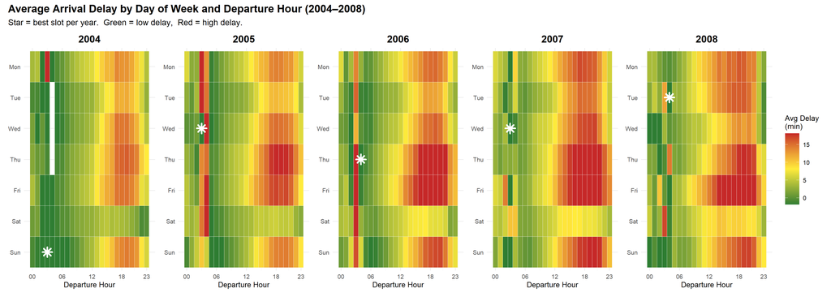

```r
all_delays <- unlist(lapply(yearly_agg, `[[`, "AvgDelay"))
vmin <- quantile(all_delays, 0.05)
vmax <- quantile(all_delays, 0.95)

make_heatmap_panel <- function(y) {
  hm       <- yearly_agg[[as.character(y)]]
  best_row <- hm[which.min(AvgDelay)]

  ggplot(hm, aes(x = DepHour,
                  y = factor(DayOfWeek, levels = 7:1),
                  fill = AvgDelay)) +
    geom_tile(color = "grey95", linewidth = 0.2) +
    geom_point(data = best_row,
               aes(x = DepHour, y = factor(DayOfWeek, levels = 7:1)),
               color = "white", shape = 8, size = 3, stroke = 1.5,
               inherit.aes = FALSE) +
    scale_fill_gradientn(
      colors = c("#2E7D32", "#FFEB3B", "#C62828"),
      limits = c(vmin, vmax),
      oob    = squish,
      name   = "Avg Delay\n(min)"
    ) +
    scale_x_continuous(breaks = c(0, 6, 12, 18, 23),
                       labels = c("00", "06", "12", "18", "23")) +
    scale_y_discrete(labels = rev(DAY_LABELS_SHORT)) +
    labs(title = as.character(y), x = "Departure Hour", y = NULL) +
    theme_minimal(base_size = 9) +
    theme(plot.title = element_text(face = "bold", hjust = 0.5, size = 12))
}

heatmap_panels <- lapply(YEARS, make_heatmap_panel)

fig1 <- wrap_plots(heatmap_panels, nrow = 1) +
  plot_layout(guides = "collect") +
  plot_annotation(
    title    = "Average Arrival Delay by Day of Week and Departure Hour (2004–2008)",
    subtitle = "Star = best slot per year.  Green = low delay,  Red = high delay.",
    theme    = theme(
      plot.title    = element_text(face = "bold", size = 13),
      plot.subtitle = element_text(size = 10)
    )
  )
print(fig1)
```

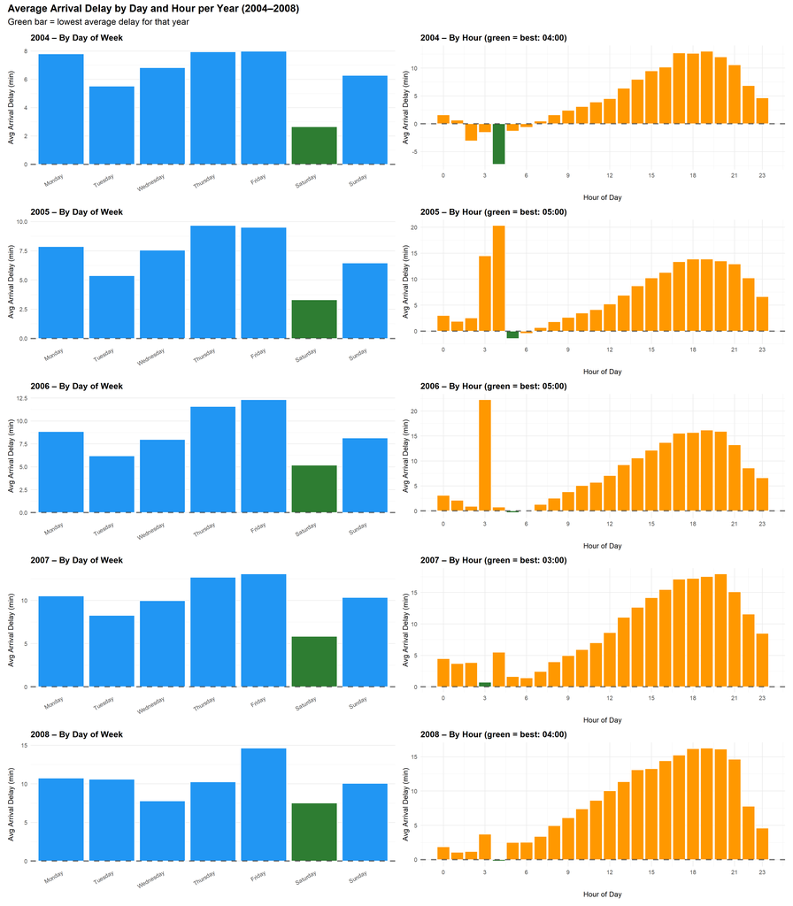

```r
make_bar_pair <- function(y) {
  day_df  <- copy(yearly_day[[as.character(y)]][order(DayOfWeek)])
  hour_df <- copy(yearly_hour[[as.character(y)]][order(DepHour)])

  best_day_idx <- which.min(day_df$AvgDelay)
  best_hr_idx  <- which.min(hour_df$AvgDelay)

  day_df[,  fill_col := "#2196F3"]
  day_df[best_day_idx, fill_col := "#2E7D32"]
  hour_df[, fill_col := "#FF9800"]
  hour_df[best_hr_idx, fill_col := "#2E7D32"]

  p_day <- ggplot(day_df,
                   aes(x = factor(DayOfWeek, levels = 1:7, labels = unname(DAY_LABELS)),
                       y = AvgDelay, fill = fill_col)) +
    geom_col(color = "white") +
    geom_hline(yintercept = 0, linetype = "dashed", alpha = 0.5, linewidth = 0.8) +
    scale_fill_identity() +
    labs(title = sprintf("%d – By Day of Week", y),
         x = NULL, y = "Avg Arrival Delay (min)") +
    theme_minimal(base_size = 9) +
    theme(axis.text.x  = element_text(angle = 30, hjust = 1),
          plot.title    = element_text(face = "bold"),
          panel.grid.major.x = element_blank())

  best_hr_val <- hour_df$DepHour[best_hr_idx]
  p_hour <- ggplot(hour_df, aes(x = DepHour, y = AvgDelay, fill = fill_col)) +
    geom_col(color = "white") +
    geom_hline(yintercept = 0, linetype = "dashed", alpha = 0.5, linewidth = 0.8) +
    scale_fill_identity() +
    scale_x_continuous(breaks = c(0, 3, 6, 9, 12, 15, 18, 21, 23)) +
    labs(title = sprintf("%d – By Hour (green = best: %02d:00)", y, best_hr_val),
         x = "Hour of Day", y = "Avg Arrival Delay (min)") +
    theme_minimal(base_size = 9) +
    theme(plot.title = element_text(face = "bold"))

  list(p_day, p_hour)
}

bar_pairs  <- lapply(YEARS, make_bar_pair)
row_panels <- lapply(bar_pairs, function(pr) pr[[1]] | pr[[2]])

fig2 <- wrap_plots(row_panels, ncol = 1) +
  plot_annotation(
    title    = "Average Arrival Delay by Day and Hour per Year (2004–2008)",
    subtitle = "Green bar = lowest average delay for that year",
    theme    = theme(plot.title = element_text(face = "bold", size = 13))
  )
print(fig2)
```

# 5. Question B – Do Older Planes Suffer More Delays?

## Approach

To test whether aircraft age is associated with higher arrival delays, plane age is computed as `flight_year − MfgYear` and clipped to [0, 80] years to remove spurious values caused by data entry errors in the tail-number registry. Flights are then grouped into six age bands (0–5, 5–10, 10–15, 15–20, 20–25, 25+) and the mean arrival delay is computed within each band for each year.

In addition to the grouped analysis, Pearson correlation is calculated on a random sample of 100,000 individual flights per year. Sampling rather than using the full dataset keeps computation manageable while still providing a stable estimate of the linear relationship between continuous plane age and delay.

```r
COLS_NEEDED_B <- c("TailNum", "ArrDelay", "Cancelled")
AGE_BREAKS    <- c(0, 5, 10, 15, 20, 25, 100)
AGE_LABELS    <- c("0-5", "5-10", "10-15", "15-20", "20-25", "25+")

age_bin_results <- list()
corr_results_b  <- list()
raw_age_delay   <- list()

for (y in YEARS) {
  path <- file.path(DATA_DIR, paste0(y, ".csv"))

  year_dt <- fread(path, select = COLS_NEEDED_B, showProgress = FALSE)
  year_dt <- year_dt[Cancelled != 1 & !is.na(ArrDelay) & !is.na(TailNum)]
  year_dt[, ArrDelay := suppressWarnings(as.numeric(ArrDelay))]
  year_dt <- year_dt[!is.na(ArrDelay)]

  mfg <- plane_lkp[year_dt$TailNum]
  mfg[is.na(mfg)] <- global_mfg_median
  year_dt[, PlaneAge := pmax(pmin(y - mfg, 80), 0)]

  year_dt[, AgeBin := cut(PlaneAge, breaks = AGE_BREAKS, labels = AGE_LABELS,
                            right = FALSE, include.lowest = TRUE)]

  bin_agg <- year_dt[, .(AvgDelay = mean(ArrDelay), Count = .N), by = AgeBin]
  bin_agg[, Year := y]
  age_bin_results[[as.character(y)]] <- bin_agg

  n_samp <- min(100000L, nrow(year_dt))
  samp   <- year_dt[sample(.N, n_samp)]
  corr   <- cor(samp$PlaneAge, samp$ArrDelay, use = "complete.obs")
  corr_results_b[[as.character(y)]] <- corr

  age_avg <- year_dt[, .(AvgDelay = mean(ArrDelay), Count = .N), by = PlaneAge]
  raw_age_delay[[as.character(y)]] <- age_avg[Count >= 100]

  rm(year_dt, samp, bin_agg, age_avg); invisible(gc())
}

corr_dt_b <- data.table(
  Year        = as.integer(names(corr_results_b)),
  PearsonCorr = unlist(corr_results_b)
)
knitr::kable(corr_dt_b, caption = "Pearson Correlation: Plane Age vs Arrival Delay (2004–2008)")
```

Pearson Correlation: Plane Age vs Arrival Delay (2004–2008)

| Year | PearsonCorr |
| --- | --- |
| 2004 | 0.0079975 |
| 2005 | 0.0065340 |
| 2006 | -0.0043655 |
| 2007 | 0.0156729 |
| 2008 | 0.0199940 |

## Question B – Plots

The left panel shows the average arrival delay for each age group across all five years on a single line chart. The right panel shows the Pearson correlation coefficient for each year. Red bars indicate a positive correlation (older = more delayed); blue would indicate a negative one. The scatter plots show the raw relationship at the level of individual plane-age values, with bubble size proportional to the number of flights at that age and a weighted trend line overlaid.

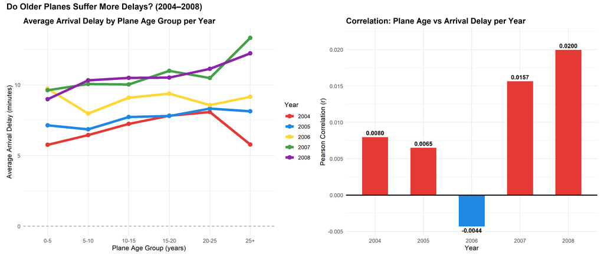

```r
bin_all <- rbindlist(age_bin_results)
bin_all[, AgeBin := factor(AgeBin, levels = AGE_LABELS)]
bin_all[, Year   := factor(Year)]

# Local colour map for this line graph (alphabetical year order → prescribed scheme)
LINE_YEAR_COLORS <- c(
  "2004" = "#E53935",  # Red
  "2005" = "#1E88E5",  # Blue
  "2006" = "#FDD835",  # Yellow
  "2007" = "#43A047",  # Green
  "2008" = "#8E24AA"   # Purple
)

p_line <- ggplot(bin_all, aes(x = AgeBin, y = AvgDelay,
                                color = Year, group = Year)) +
  geom_line(linewidth = 2) +
  geom_point(size = 3) +
  geom_hline(yintercept = 0, linetype = "dashed", alpha = 0.4) +
  scale_color_manual(values = LINE_YEAR_COLORS) +
  labs(title  = "Average Arrival Delay by Plane Age Group per Year",
       x = "Plane Age Group (years)", y = "Average Arrival Delay (minutes)",
       color = "Year") +
  theme_minimal(base_size = 11) +
  theme(plot.title = element_text(face = "bold"))

corr_dt_b[, bar_color := ifelse(PearsonCorr > 0, "#E53935", "#1E88E5")]

p_corr <- ggplot(corr_dt_b,
                  aes(x = factor(Year), y = PearsonCorr, fill = bar_color)) +
  geom_col(color = "white", width = 0.55) +
  geom_text(aes(label   = sprintf("%.4f", PearsonCorr),
                vjust   = ifelse(PearsonCorr >= 0, -0.4, 1.3)),
            fontface = "bold", size = 3.5) +
  geom_hline(yintercept = 0, linewidth = 0.8) +
  scale_fill_identity() +
  scale_y_continuous(expand = expansion(mult = c(0.05, 0.12))) +
  labs(title = "Correlation: Plane Age vs Arrival Delay per Year",
       x = "Year", y = "Pearson Correlation (r)") +
  theme_minimal(base_size = 11) +
  theme(plot.title = element_text(face = "bold"))

fig3 <- (p_line | p_corr) +
  plot_annotation(
    title = "Do Older Planes Suffer More Delays? (2004–2008)",
    theme = theme(plot.title = element_text(face = "bold", size = 14))
  )
print(fig3)
```

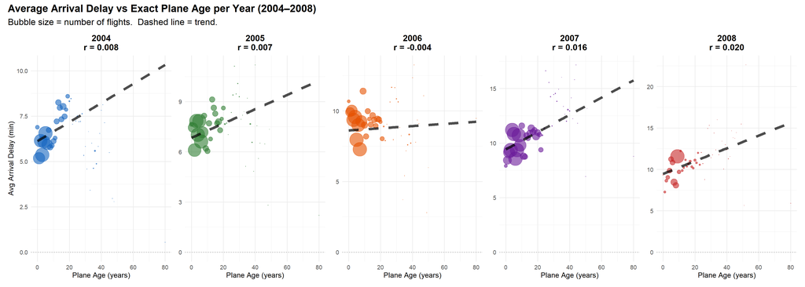

```r
scatter_panels <- lapply(YEARS, function(y) {
  df   <- raw_age_delay[[as.character(y)]]
  corr <- corr_results_b[[as.character(y)]]

  fit   <- lm(AvgDelay ~ PlaneAge, data = df, weights = Count)
  df[, trend := predict(fit)]

  ggplot(df, aes(x = PlaneAge, y = AvgDelay)) +
    geom_point(aes(size = pmin(Count / 50000, 8)),
               alpha = 0.6, color = YEAR_COLORS[as.character(y)],
               stroke = 0.4) +
    geom_line(aes(y = trend), color = "black", linewidth = 1.5,
              linetype = "dashed", alpha = 0.7) +
    geom_hline(yintercept = 0, color = "grey60", linetype = "dotted") +
    scale_size_identity() +
    labs(title = sprintf("%d\nr = %.3f", y, corr),
         x = "Plane Age (years)",
         y = if (y == 2004) "Avg Arrival Delay (min)" else NULL) +
    theme_minimal(base_size = 9) +
    theme(plot.title    = element_text(face = "bold", hjust = 0.5),
          legend.position = "none")
})

fig4 <- wrap_plots(scatter_panels, nrow = 1) +
  plot_annotation(
    title    = "Average Arrival Delay vs Exact Plane Age per Year (2004–2008)",
    subtitle = "Bubble size = number of flights.  Dashed line = trend.",
    theme    = theme(plot.title = element_text(face = "bold", size = 13))
  )
print(fig4)
```

## Question B – Findings

# 6. Question C – Logistic Regression for Flight Diversion Probability

A logistic regression model is fitted to predict whether a flight will be diverted, using only features that are known **before departure**. Two modelling challenges require explicit handling:

**Data leakage:** `WeatherDelay` and other post-flight fields are excluded — they are recorded only after a flight lands and are almost always missing for diverted flights. Including them would let the model cheat by looking at information that would not be available at prediction time.

**Class imbalance:** Diverted flights account for less than 0.3% of all records. This is handled via (1) stratified sampling in `load_year_sampled_c()`, which retains all diversions while downsampling non-diversions, and (2) balanced class weights inside `fit_logreg()`, which upweights the minority class during optimisation.

## 6.1 EDA – Feature Selection

Before fitting any model, exploratory data analysis is run on the 2006 dataset (chosen as a representative middle year) to understand how diversion rates vary across the candidate features. A sample of up to 500,000 engineered rows is loaded in chunks, then randomly reduced to 100,000 for the plots to keep rendering fast.

Three bar charts examine how the raw diversion rate shifts across distance quartiles, departure hours, and days of the week. A correlation bar chart then ranks all numeric features by their absolute Pearson correlation with the binary `Diverted` target, distinguishing positive associations (red) from negative ones (blue). This ranking informs which features are likely to carry the most signal in the regression, though all features are retained since ridge regularisation will down-weight uninformative ones automatically.

```r
eda_path    <- file.path(DATA_DIR, "2006.csv")
hdr         <- fread(eda_path, nrows = 0L)
all_cols    <- names(hdr)
needed_idx  <- which(all_cols %in% COLS_NEEDED_C)
needed_nms  <- all_cols[needed_idx]

eda_chunks  <- list()
eda_total   <- 0L
skip_lines  <- 1L

repeat {
  chunk <- tryCatch(
    fread(eda_path, skip = skip_lines, nrows = CHUNK_SIZE, header = FALSE,
          select = needed_idx, col.names = needed_nms, showProgress = FALSE),
    error = function(e) NULL
  )
  if (is.null(chunk) || nrow(chunk) == 0L) break

  n_read <- nrow(chunk)
  eng    <- engineer_chunk(chunk, 2006L)
  rm(chunk); invisible(gc())

  if (!is.null(eng)) {
    eda_chunks <- c(eda_chunks, list(eng))
    eda_total  <- eda_total + nrow(eng)
    rm(eng)
  }

  if (eda_total >= 500000L || n_read < CHUNK_SIZE) break
  skip_lines <- skip_lines + CHUNK_SIZE
}

eda_dt <- rbindlist(eda_chunks, fill = TRUE)
eda_dt <- eda_dt[sample(.N, min(100000L, .N))]
rm(eda_chunks); invisible(gc())
```

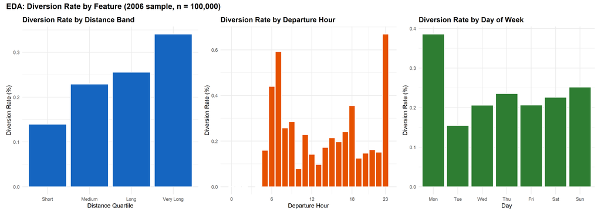

```r
eda_dt[, DistBand := cut(
  Distance,
  breaks         = quantile(Distance, probs = c(0, .25, .5, .75, 1), na.rm = TRUE),
  labels         = c("Short", "Medium", "Long", "Very Long"),
  include.lowest = TRUE
)]
dist_div <- eda_dt[, .(DivertedRate = mean(Diverted) * 100), by = DistBand][order(DistBand)]

p_eda1 <- ggplot(dist_div, aes(x = DistBand, y = DivertedRate)) +
  geom_col(fill = "#1565C0", color = "white") +
  labs(title = "Diversion Rate by Distance Band",
       x = "Distance Quartile", y = "Diversion Rate (%)") +
  theme_minimal(base_size = 10) +
  theme(plot.title = element_text(face = "bold"))

hour_div <- eda_dt[, .(DivertedRate = mean(Diverted) * 100), by = DepHour][order(DepHour)]

p_eda2 <- ggplot(hour_div, aes(x = DepHour, y = DivertedRate)) +
  geom_col(fill = "#E65100", color = "white") +
  scale_x_continuous(breaks = c(0, 6, 12, 18, 23)) +
  labs(title = "Diversion Rate by Departure Hour",
       x = "Departure Hour", y = "Diversion Rate (%)") +
  theme_minimal(base_size = 10) +
  theme(plot.title = element_text(face = "bold"))

dow_div <- eda_dt[, .(DivertedRate = mean(Diverted) * 100), by = DayOfWeek][order(DayOfWeek)]
dow_div[, DayName := factor(DAY_LABELS_SHORT[as.character(DayOfWeek)],
                              levels = DAY_LABELS_SHORT)]

p_eda3 <- ggplot(dow_div, aes(x = DayName, y = DivertedRate)) +
  geom_col(fill = "#2E7D32", color = "white") +
  labs(title = "Diversion Rate by Day of Week",
       x = "Day", y = "Diversion Rate (%)") +
  theme_minimal(base_size = 10) +
  theme(plot.title = element_text(face = "bold"))

fig_eda <- (p_eda1 | p_eda2 | p_eda3) +
  plot_annotation(
    title = "EDA: Diversion Rate by Feature (2006 sample, n = 100,000)",
    theme = theme(plot.title = element_text(face = "bold", size = 13))
  )
print(fig_eda)
```

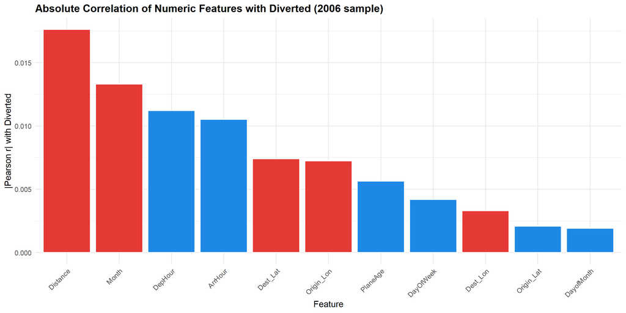

```r
corr_with_target <- sapply(NUMERIC_FEATURES_C, function(col) {
  cor(eda_dt[[col]], eda_dt$Diverted, use = "complete.obs")
})
corr_dt_eda <- data.table(
  Feature = names(corr_with_target),
  AbsCorr = abs(corr_with_target),
  RawCorr = corr_with_target
)[order(-AbsCorr)]
corr_dt_eda[, bar_color := ifelse(RawCorr > 0, "#E53935", "#1E88E5")]

p_corr_eda <- ggplot(corr_dt_eda,
                      aes(x = reorder(Feature, -AbsCorr), y = AbsCorr,
                          fill = bar_color)) +
  geom_col(color = "white") +
  scale_fill_identity() +
  labs(title = "Absolute Correlation of Numeric Features with Diverted (2006 sample)",
       x = "Feature", y = "|Pearson r| with Diverted") +
  theme_minimal(base_size = 10) +
  theme(plot.title  = element_text(face = "bold"),
        axis.text.x = element_text(angle = 45, hjust = 1))

print(p_corr_eda)
```

```r
rm(eda_dt); invisible(gc())
```

## 6.2 Part A – Per-Year Coefficient Analysis

A separate ridge logistic regression is fitted on each year’s data independently. This lets us track how each feature’s log-odds contribution to diversion risk changes over time — for example, whether the influence of flight distance or carrier identity became stronger or weaker as the network evolved between 2004 and 2008.

Each year’s model uses the stratified sample produced by `load_year_sampled_c()`. The coefficients are extracted and assembled into a long-format table (`coef_long`) with one row per feature per year, with missing coefficients (features that appear in some years but not others, typically due to sparse carrier encoding) filled with zero.

```r
coefs_list  <- list()
auc_train_c <- list()

for (y in YEARS) {

  sample_dt <- load_year_sampled_c(y, target_size = SAMPLE_SIZE)
  if (is.null(sample_dt)) next

  y_vec <- sample_dt$Diverted
  X_dt  <- sample_dt[, ALL_FEATURES_C, with = FALSE]

  fit <- fit_logreg(X_dt, y_vec)

  probs     <- as.vector(predict(fit$model, newx = fit$X_mat,
                                  s = fit$lambda, type = "response"))
  roc_train <- roc(y_vec, probs, quiet = TRUE)
  auc_val   <- as.numeric(auc(roc_train))
  auc_train_c[[as.character(y)]] <- auc_val

  coefs_list[[as.character(y)]] <- fit$coef_vec

  rm(sample_dt, X_dt, y_vec, fit, probs, roc_train); invisible(gc())
}

all_feat_nms <- unique(unlist(lapply(coefs_list, names)))
coef_dt <- data.table(Feature = all_feat_nms)
for (y_chr in names(coefs_list)) {
  cv <- coefs_list[[y_chr]]
  coef_dt[[y_chr]] <- cv[coef_dt$Feature]
}

# Zero-fill NA coefficients (features absent in some years)
year_cols <- setdiff(names(coef_dt), "Feature")
for (col in year_cols) {
  set(coef_dt, i = which(is.na(coef_dt[[col]])), j = col, value = 0)
}

coef_long <- melt(coef_dt, id.vars = "Feature",
                   variable.name = "Year", value.name = "Coef")
coef_long[, Year := as.integer(as.character(Year))]
```

## 6.3 Part B – Prediction on Unseen 2008 Data

To assess whether the model generalises beyond its training period, a combined model is trained on 2004–2007 data and then evaluated on held-out 2008 flights. This is a strict temporal train/test split — the model never sees any 2008 data during training, which gives a realistic estimate of how well it would perform if deployed in practice.

Each training year contributes up to 1,000,000 sampled rows (stratified as before). The test set is an independent stratified sample from 2008. Performance is reported as AUC-ROC (which is threshold-independent) as well as precision, recall, and F1 at a 0.5 decision threshold. Low precision and F1 are expected given the extreme class imbalance — fewer than 0.3% of flights are diverted — so AUC is the primary metric of interest.

```r
train_frames <- list()
for (y in TRAIN_YEARS) {
  s <- load_year_sampled_c(y, target_size = 1000000L)
  if (!is.null(s)) {
    train_frames[[as.character(y)]] <- s
    rm(s)
  }
  invisible(gc())
}
train_dt <- rbindlist(train_frames, fill = TRUE)
rm(train_frames); invisible(gc())

test_dt <- load_year_sampled_c(TEST_YEAR, target_size = 1000000L)

if (is.null(test_dt)) {
  stop(sprintf(
    "No diverted flights found in %d — cannot evaluate prediction model.", TEST_YEAR
  ))
}

X_train <- train_dt[, ALL_FEATURES_C, with = FALSE]
y_train <- train_dt$Diverted
X_test  <- test_dt[, ALL_FEATURES_C, with = FALSE]
y_test  <- test_dt$Diverted

pred_fit <- fit_logreg(X_train, y_train)
y_prob   <- predict_prob(pred_fit, X_test)
y_pred   <- as.integer(y_prob > 0.5)

roc_obj  <- roc(y_test, y_prob, quiet = TRUE)
test_auc <- as.numeric(auc(roc_obj))

tp <- sum(y_pred == 1L & y_test == 1L)
fp <- sum(y_pred == 1L & y_test == 0L)
fn <- sum(y_pred == 0L & y_test == 1L)
tn <- sum(y_pred == 0L & y_test == 0L)

test_prec <- ifelse(tp + fp > 0, tp / (tp + fp), 0)
test_rec  <- ifelse(tp + fn > 0, tp / (tp + fn), 0)
test_f1   <- ifelse(test_prec + test_rec > 0,
                     2 * test_prec * test_rec / (test_prec + test_rec), 0)

roc_df <- data.table(fpr = 1 - roc_obj$specificities,
                      tpr = roc_obj$sensitivities)

results_table <- data.table(
  Metric = c("AUC-ROC", "Recall", "Precision", "F1 Score"),
  Value = c(test_auc, test_rec, test_prec, test_f1)
)
knitr::kable(results_table, caption = "Model Performance on Unseen 2008 Test Data", digits = 4)
```

Model Performance on Unseen 2008 Test Data

| Metric | Value |
| --- | --- |
| AUC-ROC | 0.6507 |
| Recall | 0.6242 |
| Precision | 0.0086 |
| F1 Score | 0.0170 |

```r
confusion_matrix <- matrix(c(tn, fn, fp, tp), nrow = 2,
                           dimnames = list(Actual = c("0","1"), Predicted = c("0","1")))
knitr::kable(confusion_matrix, caption = "Confusion Matrix: Test Set (2008)")
```

Confusion Matrix: Test Set (2008)

|  | 0 | 1 |
| --- | --- | --- |
| 0 | 589204 | 405142 |
| 1 | 2125 | 3529 |

```r
rm(train_dt, X_train, y_train); invisible(gc())
```

## 6.4 Plots

Four visualisations are produced for Question C:

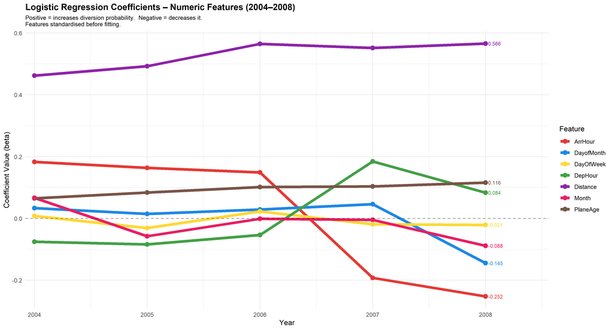

```r
plot_num_cols <- setdiff(NUMERIC_FEATURES_C,
                          c("Origin_Lat", "Origin_Lon", "Dest_Lat", "Dest_Lon"))

# Alphabetical feature order → prescribed colour scheme
FEATURE_COLORS <- c(
  "ArrHour"    = "#E53935",  # 1 Red
  "DayofMonth" = "#1E88E5",  # 2 Blue
  "DayOfWeek"  = "#FDD835",  # 3 Yellow
  "DepHour"    = "#43A047",  # 4 Green
  "Distance"   = "#8E24AA",  # 5 Purple
  "Month"      = "#E91E63",  # 6 Pink
  "PlaneAge"   = "#795548"   # 7 Brown
)

coef_trends_num <- coef_long[Feature %in% plot_num_cols]
coef_trends_num[, Feature := factor(Feature, levels = sort(unique(Feature)))]
labels_dt       <- coef_trends_num[Year == max(Year)]

p5 <- ggplot(coef_trends_num,
              aes(x = Year, y = Coef, color = Feature, group = Feature)) +
  geom_line(linewidth = 2) +
  geom_point(size = 3) +
  geom_text(data  = labels_dt,
            aes(label = sprintf("%.3f", Coef)),
            hjust = -0.2, size = 2.8, show.legend = FALSE) +
  geom_hline(yintercept = 0, linetype = "dashed", alpha = 0.4) +
  scale_x_continuous(breaks = YEARS, expand = expansion(mult = c(0.02, 0.14))) +
  scale_color_manual(values = FEATURE_COLORS) +
  labs(
    title    = "Logistic Regression Coefficients – Numeric Features (2004–2008)",
    subtitle = paste0(
      "Positive = increases diversion probability.  Negative = decreases it.\n",
      "Features standardised before fitting."
    ),
    x = "Year", y = "Coefficient Value (beta)", color = "Feature"
  ) +
  theme_minimal(base_size = 11) +
  theme(plot.title    = element_text(face = "bold"),
        plot.subtitle = element_text(size = 9),
        legend.position = "right")

print(p5)
```

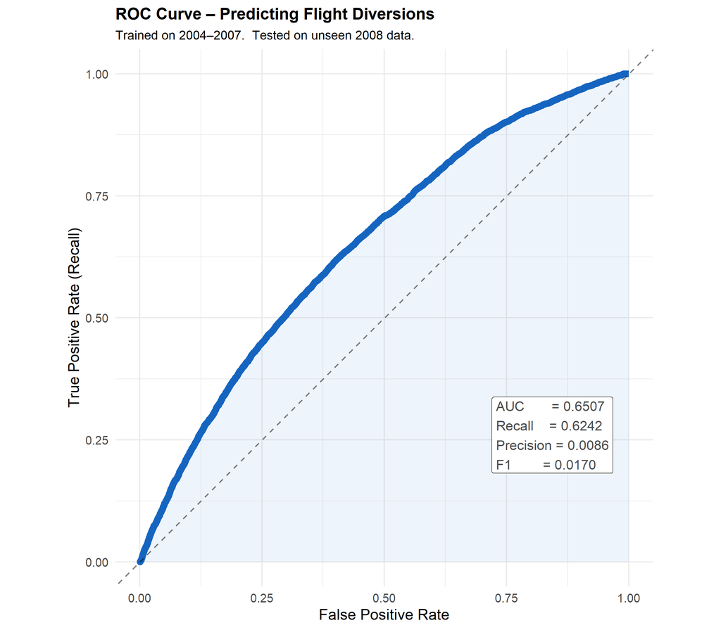

```r
p6 <- ggplot(roc_df, aes(x = fpr, y = tpr)) +
  geom_ribbon(aes(ymin = 0, ymax = tpr), fill = "#1565C0", alpha = 0.07) +
  geom_line(color = "#1565C0", linewidth = 2.5) +
  geom_abline(slope = 1, intercept = 0,
              linetype = "dashed", color = "black", alpha = 0.5) +
  annotate("label",
           x     = 0.72, y = 0.26,
           label = sprintf("AUC       = %.4f\nRecall    = %.4f\nPrecision = %.4f\nF1        = %.4f",
                            test_auc, test_rec, test_prec, test_f1),
           hjust = 0, size = 3.8, fill = "white", color = "grey30",
           label.size = 0.3) +
  labs(
    title    = "ROC Curve – Predicting Flight Diversions",
    subtitle = sprintf("Trained on 2004–2007.  Tested on unseen %d data.", TEST_YEAR),
    x = "False Positive Rate", y = "True Positive Rate (Recall)"
  ) +
  coord_equal() +
  theme_minimal(base_size = 12) +
  theme(plot.title    = element_text(face = "bold", size = 13),
        plot.subtitle = element_text(size = 10))

print(p6)
```

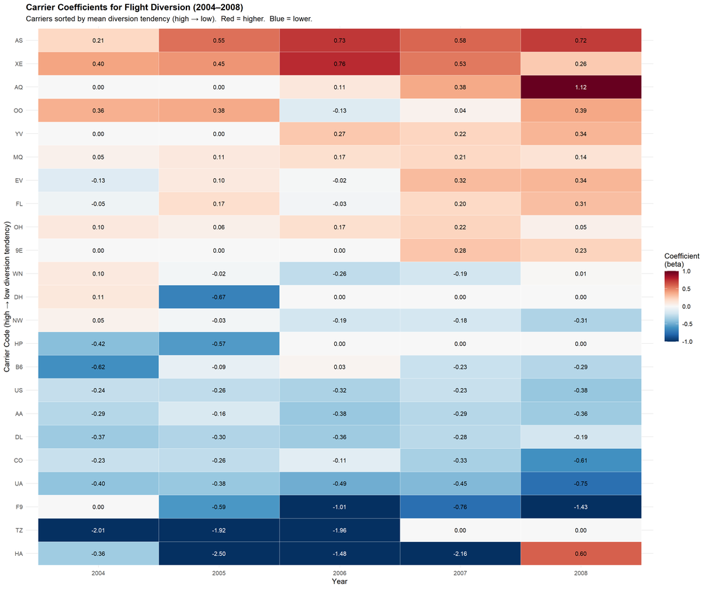

```r
carrier_dt <- coef_long[grepl("^UniqueCarrier", Feature)]
carrier_dt[, Carrier := sub("UniqueCarrier", "", Feature)]

# Sort carriers by mean coefficient value (highest diversion tendency at top)
carrier_means_order <- carrier_dt[, .(MeanCoef = mean(Coef, na.rm = TRUE)), by = Carrier]
carrier_means_order <- carrier_means_order[order(MeanCoef)]          # low → high
carrier_dt[, Carrier := factor(Carrier, levels = carrier_means_order$Carrier)]  # high at top

abs_max <- quantile(abs(carrier_dt$Coef), 0.95, na.rm = TRUE)

p7 <- ggplot(carrier_dt, aes(x = factor(Year), y = Carrier, fill = Coef)) +
  geom_tile(color = "white") +
  geom_text(
    aes(label = sprintf("%.2f", Coef),
        color = ifelse(abs(Coef) > abs_max * 0.55, "white", "black")),
    size = 2.5
  ) +
  scale_fill_gradientn(
    colors = rev(brewer.pal(11, "RdBu")),
    limits = c(-1, 1),
    oob    = squish,
    name   = "Coefficient\n(beta)"
  ) +
  scale_color_identity() +
  labs(
    title    = "Carrier Coefficients for Flight Diversion (2004–2008)",
    subtitle = "Carriers sorted by mean diversion tendency (high → low).  Red = higher.  Blue = lower.",
    x = "Year", y = "Carrier Code (high → low diversion tendency)"
  ) +
  theme_minimal(base_size = 9) +
  theme(plot.title = element_text(face = "bold"))

print(p7)
```

### Carrier Diversion Rate Table

Maps IATA codes to full airline names using `carrier_name_lkp` loaded at setup, then identifies the carriers with the highest and lowest mean diversion coefficient across 2004–2008.

```r
# Uses carrier_name_lkp loaded in Section 2 (no re-read of carriers.csv)
carrier_means <- carrier_dt[, .(MeanCoef = mean(Coef, na.rm = TRUE)),
                             by = Carrier][order(MeanCoef)]

highest_code <- carrier_means[.N, Carrier]
lowest_code  <- carrier_means[1L, Carrier]

highest_name <- carrier_name_lkp[highest_code]
lowest_name  <- carrier_name_lkp[lowest_code]
if (is.na(highest_name)) highest_name <- highest_code
if (is.na(lowest_name))  lowest_name  <- lowest_code

highest_coef <- carrier_means[.N, MeanCoef]
lowest_coef  <- carrier_means[1L, MeanCoef]

carrier_summary <- data.frame(
  Tendency       = c("Highest diversion tendency", "Lowest diversion tendency"),
  `Carrier Code` = c(highest_code, lowest_code),
  `Airline Name` = c(highest_name, lowest_name),
  `Mean Beta`    = round(c(highest_coef, lowest_coef), 4),
  check.names    = FALSE
)
knitr::kable(
  carrier_summary,
  caption = "Carriers with extreme diversion tendencies – mean coefficient across 2004–2008.",
  align   = c("l", "c", "l", "r")
)
```

Carriers with extreme diversion tendencies – mean coefficient across 2004–2008.

[output not shown]

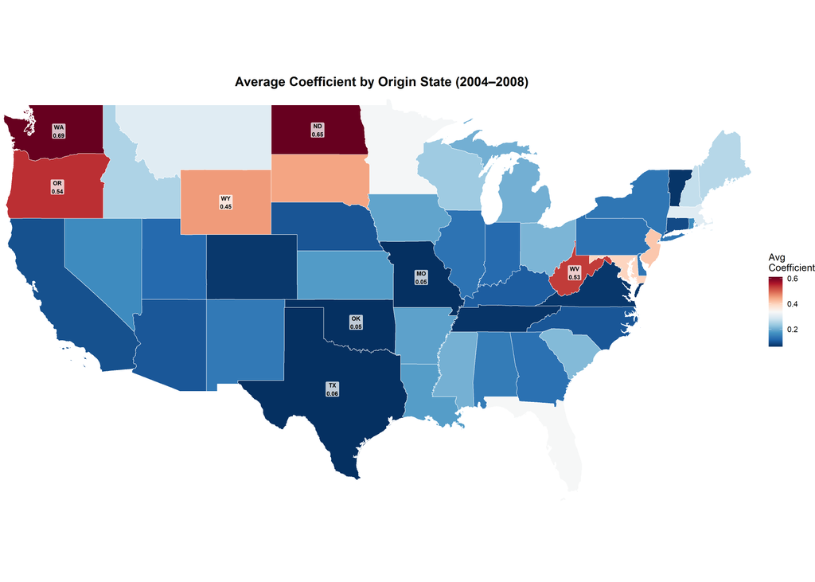

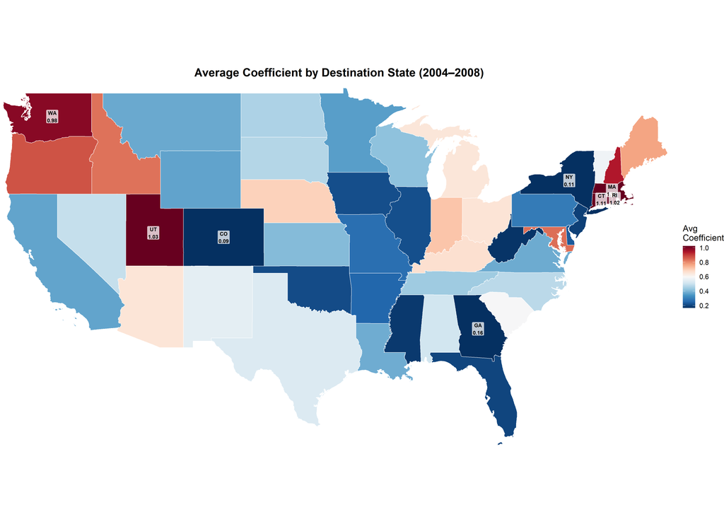

```r
shapefile_path <- file.path(BASE_DIR, "data", "shapefiles", "cb_2024_us_state_500k.shp")

us <- tryCatch({
  sf_obj <- st_read(shapefile_path, quiet = TRUE)
  sf_obj[!is.na(sf_obj$STUSPS), ]
}, error = function(e) {
  cat(sprintf("Shapefile not found or error: %s\nState maps skipped.\n", e$message))
  NULL
})

if (!is.null(us)) {
  plot_state_map <- function(feature_prefix, title_str, filename) {
    state_coefs <- coef_long[grepl(paste0("^", feature_prefix), Feature)]
    state_coefs[, State := sub(feature_prefix, "", Feature)]
    state_avg <- state_coefs[, .(coef_val = mean(abs(Coef), na.rm = TRUE)), by = State]

    merged      <- dplyr::left_join(us, state_avg, by = c("STUSPS" = "State"))
    merged_cont <- merged[!merged$STUSPS %in%
                            c("AK","HI","PR","VI","GU","MP","AS"), ]

    valid_vals <- state_avg$coef_val
    vmin_s <- quantile(valid_vals, 0.05, na.rm = TRUE)
    vmax_s <- quantile(valid_vals, 0.95, na.rm = TRUE)

    suppressWarnings({ centroids <- st_centroid(merged_cont) })
    coords_df <- as.data.frame(st_coordinates(centroids))
    ann_df <- data.frame(STUSPS = merged_cont$STUSPS,
                          coef_val = merged_cont$coef_val,
                          X = coords_df$X, Y = coords_df$Y,
                          stringsAsFactors = FALSE)
    ann_df <- ann_df[!is.na(ann_df$coef_val) &
                       ann_df$X > -125 & ann_df$X < -66 &
                       ann_df$Y > 24   & ann_df$Y < 50, ]

    top5     <- ann_df[order(-ann_df$coef_val), ][seq_len(min(5, nrow(ann_df))), ]
    bot3     <- ann_df[order( ann_df$coef_val), ][seq_len(min(3, nrow(ann_df))), ]
    ann_show <- unique(rbind(top5, bot3))

    p <- ggplot() +
      geom_sf(data = merged_cont[is.na(merged_cont$coef_val), ],
              fill = "#cccccc", color = "white", linewidth = 0.3) +
      geom_sf(data = merged_cont[!is.na(merged_cont$coef_val), ],
              aes(fill = coef_val), color = "white", linewidth = 0.3) +
      geom_label(data = ann_show,
                 aes(x = X, y = Y,
                     label = sprintf("%s\n%.2f", STUSPS, coef_val)),
                 size = 2.5, fontface = "bold", fill = "white", alpha = 0.75,
                 label.size = 0, label.padding = unit(0.15, "lines")) +
      scale_fill_gradientn(
        colors = rev(brewer.pal(11, "RdBu")),
        limits = c(vmin_s, vmax_s), oob = squish, name = "Avg\nCoefficient"
      ) +
      coord_sf(xlim = c(-125, -66), ylim = c(24, 50), expand = FALSE) +
      labs(title = title_str) +
      theme_void(base_size = 12) +
      theme(plot.title = element_text(face = "bold", size = 16, hjust = 0.5),
            legend.position = "right")

    print(p)

  }

  if (any(grepl("^Origin_State", coef_long$Feature)))
    plot_state_map("Origin_State",
                   "Average Coefficient by Origin State (2004–2008)",
                   "q3_origin_state_heatmap.png")

  if (any(grepl("^Dest_State", coef_long$Feature)))
    plot_state_map("Dest_State",
                   "Average Coefficient by Destination State (2004–2008)",
                   "q3_dest_state_heatmap.png")
}
```

# 7. Summary of All Findings

[output not shown]